# HBSC: Data Overview and Prep

Updated: 2026-08-28

```r
rm(list = ls())

setwd("C:/MisLocalFiles/Github/HBSC/scripts")
project_folder <- "C:/MisLocalFiles/Github/HBSC/"

require(tidyverse)
require(broom)
require(naniar)
library(purrr)
library(patchwork)
library(knitr)
```

## Dataset Overview

```r
hbsc2018 <- read_delim(paste0(project_folder,
                                  "/data/raw/HBSC2018OAed1.1.csv"),
                       delim = ";",
                       na = c("", " "))
# working copy
dat <- hbsc2018
```

File has the following rows and columns:

```r
dim(hbsc2018)
```

```
[1] 244097    120
```

Pretty much all columns have missing values so need to address later. Though it seems much of the variables I will care about don’t have much.

```r
na_cnts <- data.frame(
  variable = names(dat),
  na_count = sapply(dat, function(x) sum(is.na(x)))
)

row.names(na_cnts) <- NULL

na_cnts <- na_cnts %>%
  mutate(na_pct = round(100 * na_count / nrow(dat),1)) %>%
  arrange(desc(na_count))

print(na_cnts)
```

| variable | na_count | na_pct |
| --- | --- | --- |
| agesex | 228488 | 93.6 |
| contraceptpill | 228448 | 93.6 |
| contraceptcondom | 228070 | 93.4 |
| employnotfa | 224524 | 92.0 |
| employnotmo | 199890 | 81.9 |
| hadsex | 162986 | 66.8 |
| cannabis30d_2 | 144442 | 59.2 |
| cannabisltm_2 | 142745 | 58.5 |
| countrybornfa | 71901 | 29.5 |
| countrybornmo | 70659 | 28.9 |

[output cut: 110 more lines]

```r
NA
```

### seqno_int

This is the unique identifier of each record and I confirmed it’s unique.

```r
length(unique(dat$seqno_int)) == nrow(dat)
```

```
[1] TRUE
```

### countryno

Number of countries in dataset is:

```r
length(unique(dat$countryno))
```

```
[1] 47
```

And this is the count of survey responses by country:

```r
recode_map <- c(
  "8000"   = "Albania",
  "31000"  = "Azerbaijan",
  "40000"  = "Austria",
  "51000"  = "Armenia",
  "56001"  = "Belgium (Flemish)",
  "56002"  = "Belgium (French)",
  "100000" = "Bulgaria",
  "124000" = "Canada",
  "191000" = "Croatia",
  "203000" = "Czech Republic",
  "208000" = "Denmark",
  "233000" = "Estonia",
  "246000" = "Finland",
  "250000" = "France",
  "268000" = "Georgia",
  "276000" = "Germany",
  "300000" = "Greece",
  "304000" = "Greenland",
  "348000" = "Hungary",
  "352000" = "Iceland",
  "372000" = "Ireland",
  "376000" = "Israel",
  "380000" = "Italy",
  "398000" = "Kazakhstan",
  "428000" = "Latvia",
  "440000" = "Lithuania",
  "442000" = "Luxembourg",
  "470000" = "Malta",
  "498000" = "Republic of Moldova",
  "528000" = "Netherlands",
  "578000" = "Norway",
  "616000" = "Poland",
  "620000" = "Portugal",
  "642000" = "Romania",
  "643000" = "Russia",
  "688000" = "Serbia",
  "703000" = "Slovakia",
  "705000" = "Slovenia",
  "724000" = "Spain",
  "752000" = "Sweden",
  "756000" = "Switzerland",
  "792000" = "Turkey",
  "804000" = "Ukraine",
  "807000" = "Macedonia",
  "826001" = "England",
  "826002" = "Scotland",
  "826003" = "Wales",
  "826004" = "Northern Ireland",
  "840000" = "USA"
)

dat$country_name <- recode_map[as.character(dat$countryno)]

dat %>%
  group_by(country_name) %>%
  summarise(n = n(),
            .groups = "drop") %>%
  mutate(pct = round(100 * n / sum(n),1)) %>%
  arrange(desc(n)) %>%
  print(n=Inf)
```

| country_name | n | pct |
| --- | --- | --- |
| Wales | 15951 | 6.5 |
| Canada | 12950 | 5.3 |
| Czech Republic | 11564 | 4.7 |
| France | 9170 | 3.8 |
| NA | 8411 | 3.4 |
| Israel | 7712 | 3.2 |
| Switzerland | 7510 | 3.1 |
| Iceland | 6996 | 2.9 |
| Ukraine | 6660 | 2.7 |
| Portugal | 6126 | 2.5 |

[output cut: 36 more lines]

```r
NA
```

## Variables to Predict

### lifesat

Q: Here is a picture of a ladder. The top of the ladder “10” is the best possible life for you and the bottom “0” is the worst possible life for you. In general, where on the ladder do you feel you stand at the moment? A: 0-10

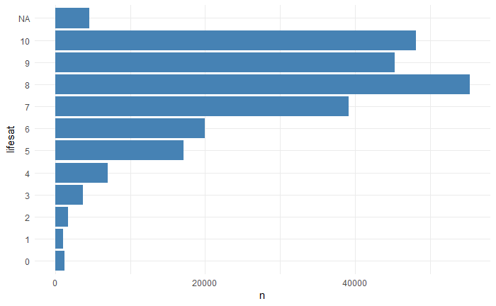

```r
ggplot(dat, aes(y = factor(lifesat))) +
  geom_bar(fill = "steelblue") +
  labs(
    y = "lifesat",
    x = "n"
    ) +
  theme_minimal()
```

lifesat is dichotomized for modeling as lifesat_low:

```r
dat <- dat %>%
  mutate(
    lifesat_low = case_when(
      between(lifesat, 0, 5) ~ 1,
      between(lifesat, 6, 10) ~ 0,
      TRUE ~ NA))

table(dat$lifesat,
      dat$lifesat_low,
      useNA = "always"
      )
```

```
           0     1  <NA>
  0        0  1218     0
  1        0  1041     0
  2        0  1748     0
  3        0  3691     0
  4        0  6961     0
  5        0 17137     0
  6    19921     0     0
  7    39120     0     0
  8    55325     0     0
  9    45271     0     0
  10   48152     0     0
  <NA>     0     0  4512
```

Ultimately the distribution is:

```r
dat %>%
  group_by(lifesat_low) %>%
  summarise(n = n()) %>%
  mutate(pct = n / sum(n))
```

| lifesat_low | n | pct |
| --- | --- | --- |
| 0 | 207789 | 0.85125585 |
| 1 | 31796 | 0.13025969 |
| NA | 4512 | 0.01848445 |

```r
NA
```

### (mental) health complaints

There are 8 variables for this that reply to a question like: In the last 6 months: how often have you had the following….? And the answers goes from 1 About every day to 5 Rarely or never. The 8 variables are: headache, stomachache, backache, dizzy, feellow, irritable, nervous, sleepdificulty.

Their distributions look like this:

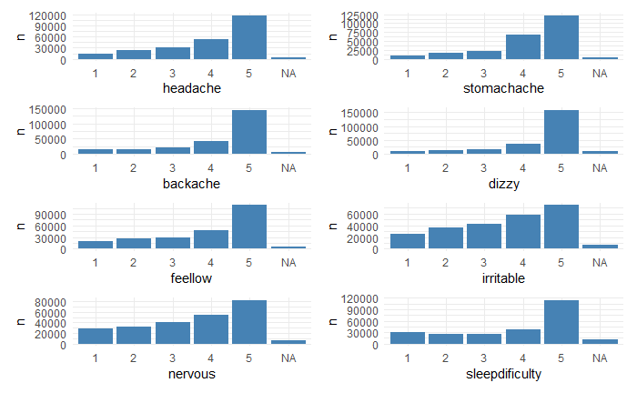

```r
vars_health_complaints <- c("headache", "stomachache", "backache", "dizzy",
          "feellow", "irritable", "nervous", "sleepdificulty")

plot_list <- map(vars_health_complaints, function(v) {
  ggplot(dat, aes(y = factor(.data[[v]]))) +
    geom_bar(fill = "steelblue") +
    coord_flip() +
    labs(
      y = v,
      x = "n"
    ) +
    theme_minimal()
})

wrap_plots(plot_list, ncol = 2)
```

These variables are then recoded to a binary where it flags if the complaint occurs more than once per week (1 or 2).

```r
dat <- dat %>%
  mutate(
    headache_frequent = ifelse(headache <= 2, 1, 0),
    stomachache_frequent = ifelse(stomachache <= 2, 1, 0),
    backache_frequent = ifelse(backache <= 2, 1, 0),
    dizzy_frequent = ifelse(dizzy <= 2, 1, 0),
    feellow_frequent = ifelse(feellow <= 2, 1, 0),
    irritable_frequent = ifelse(irritable <= 2, 1, 0),
    nervous_frequent = ifelse(nervous <= 2, 1, 0),
    sleepdificulty_frequent = ifelse(sleepdificulty <= 2, 1, 0)
  )
```

The recoded variables look like this:

```r
vars_health_complaints_frequent <- paste0(vars_health_complaints,
                                          "_frequent")

for (i in seq_along(vars_health_complaints)) {
  cat("\n\n###", vars_health_complaints[i], "x", vars_health_complaints_frequent[i], "\n")
  print(table(dat[[vars_health_complaints[i]]], dat[[vars_health_complaints_frequent[i]]], useNA = "always"))
}
```

```
### headache x headache_frequent

            0      1   <NA>
  1         0  13883      0
  2         0  24257      0
  3     30076      0      0
  4     53676      0      0
  5    117700      0      0
  <NA>      0      0   4505


### stomachache x stomachache_frequent

            0      1   <NA>
  1         0   8415      0
  2         0  16223      0
  3     22895      0      0
  4     68018      0      0
  5    122867      0      0
  <NA>      0      0   5679


### backache x backache_frequent

            0      1   <NA>
  1         0  14872      0
  2         0  16137      0
  3     21410      0      0
  4     40910      0      0
  5    144225      0      0
  <NA>      0      0   6543


### dizzy x dizzy_frequent

            0      1   <NA>
  1         0  10461      0
  2         0  14272      0
  3     17261      0      0
  4     35189      0      0
```

[output cut: 31 more lines]

```
  3    40064     0     0
  4    54109     0     0
  5    82323     0     0
  <NA>     0     0  6525


### sleepdificulty x sleepdificulty_frequent

            0      1   <NA>
  1         0  30501      0
  2         0  25543      0
  3     26053      0      0
  4     36570      0      0
  5    114616      0      0
  <NA>      0      0  10814
```

The frequency of complaints is then added to calculate one sum for physical and one for mental. If the sum is 2 or more then it is determined that there is a health issue. Most papers do it for psycosomatic (all 8 vars) but I will focus on the 4 mental ones. Still, I include both vars in case.

```r
dat <- dat %>%
  # add the frequency of complaints
  mutate(mental_complaints_sum = feellow_frequent +
                           irritable_frequent +
                           nervous_frequent +
                           sleepdificulty_frequent,
         physical_complaints_sum = headache_frequent +
                           stomachache_frequent +
                           backache_frequent +
                           dizzy_frequent
  ) %>%
  # derive index based on sum
  mutate(mental_complaintsY = ifelse(mental_complaints_sum >=2, 1, 0),
         health_complaintsY = ifelse((mental_complaints_sum + physical_complaints_sum) >=2, 1, 0)
      )

cat("\n\n### mental_complaintsY x mental_complaints_sum\n")
```

```
### mental_complaintsY x mental_complaints_sum
```

```r
table(dat$mental_complaints_sum,
      dat$mental_complaintsY,
      useNA = "always")
```

```
            0      1   <NA>
  0    121573      0      0
  1     45509      0      0
  2         0  29991      0
  3         0  21172      0
  4         0  12970      0
  <NA>      0      0  12882
```

```r
cat("\n\n### (health_complaintsY x health_complaints_sum\n")
```

```
### (health_complaintsY x health_complaints_sum
```

```r
table(dat$mental_complaints_sum + dat$physical_complaints_sum,
      dat$health_complaintsY,
      useNA = "always")
```

```
            0      1   <NA>
  0    103678      0      0
  1     41923      0      0
  2         0  29221      0
  3         0  21360      0
  4         0  14640      0
  5         0   8824      0
  6         0   5202      0
  7         0   2839      0
  8         0   2219      0
  <NA>      0      0  14191
```

### mental_complaintsY

Ultimately our variable to predict will be mental_complaintsY; at ~26%.

```r
dat %>%
  group_by(mental_complaintsY) %>%
  summarise(n = n()) %>%
  mutate(pct = n / sum(n))
```

| mental_complaintsY | n | pct |
| --- | --- | --- |
| 0 | 167082 | 0.6844902 |
| 1 | 64133 | 0.2627357 |
| NA | 12882 | 0.0527741 |

```r
NA
```

## The Predictors

### Problematic social media use (PMSU)

PMSU are the main variables of interest. There are 9 of them: emcsocmed1 to emcsocmed9. The prequestion for all of them is: We are interested in your experiences with social media. The term social media refers to social network sites (e.g. Facebook, [add other local examples]) and instant messengers (e.g. [insert local examples], WhatsApp, Snapchat, Facebook messenger). During the past year, have you…. Please tick one box for each line.

The possible answers are 1 (no) and 2 (yes). Also those with 99 mean Missing due to skip pattern.

The topic of each question is:

```r
questions <- data.frame(
  item = c(
    "emcsocmed1","emcsocmed2","emcsocmed3","emcsocmed4",
    "emcsocmed5","emcsocmed6","emcsocmed7","emcsocmed8","emcsocmed9"
  ),
  topic = c(
    "Social media: I can't think of anything else",
    "Social media: Dissatisfied cause want to spend more time",
    "Social media: Felt bad cause want to play",
    "Social media: Failed to spend less time",
    "Social media: Neglected other activities",
    "Social media: Had arguments because of use",
    "Social media: Lied about amount of time spent",
    "Social media: Use it to escape from negative feelings",
    "Social media: Conflict with family because of use"
  )
)

kable(questions) #, caption = "Social Media Use Items")
```

| item | topic |
| --- | --- |
| emcsocmed1 | Social media: I can’t think of anything else |
| emcsocmed2 | Social media: Dissatisfied cause want to spend more time |
| emcsocmed3 | Social media: Felt bad cause want to play |
| emcsocmed4 | Social media: Failed to spend less time |
| emcsocmed5 | Social media: Neglected other activities |
| emcsocmed6 | Social media: Had arguments because of use |
| emcsocmed7 | Social media: Lied about amount of time spent |
| emcsocmed8 | Social media: Use it to escape from negative feelings |
| emcsocmed9 | Social media: Conflict with family because of use |

```r
NA
```

Since I need to get a sum of them I will recode them from 1/2 to 0/1.These are the distributions of the answers. I put the 99 as NA - is that correct?

The recoding looks like this:

```r
# recode emcsocmed to 0/1 from 1/2
recode_emcsocmed <- function(old_col){
  new_col <- case_when(
    old_col == 1 ~ 0,
    old_col == 2 ~ 1,
    TRUE ~ NA #99?
  )
  return(new_col)
}

dat <- dat %>%
  mutate(emcsocmed1_r = recode_emcsocmed(emcsocmed1),
         emcsocmed2_r = recode_emcsocmed(emcsocmed2),
         emcsocmed3_r = recode_emcsocmed(emcsocmed3),
         emcsocmed4_r = recode_emcsocmed(emcsocmed4),
         emcsocmed5_r = recode_emcsocmed(emcsocmed5),
         emcsocmed6_r = recode_emcsocmed(emcsocmed6),
         emcsocmed7_r = recode_emcsocmed(emcsocmed7),
         emcsocmed8_r = recode_emcsocmed(emcsocmed8),
         emcsocmed9_r = recode_emcsocmed(emcsocmed9)
         )

vars <- paste0("emcsocmed", 1:9)

for (v in vars) {
  cat("## Table for", v)
  print(table(dat[[v]], dat[[paste0(v, "_r")]], useNA = "always"))
  cat("\n\n")
}
```

```
## Table for emcsocmed1
            0      1   <NA>
  1    156598      0      0
  2         0  44267      0
  99        0      0  11259
  <NA>      0      0  31973


## Table for emcsocmed2
            0      1   <NA>
  1    163166      0      0
  2         0  38013      0
  99        0      0  11259
  <NA>      0      0  31659


## Table for emcsocmed3
            0      1   <NA>
  1    157891      0      0
  2         0  42938      0
  99        0      0  11259
  <NA>      0      0  32009


## Table for emcsocmed4
            0      1   <NA>
  1    138631      0      0
  2         0  61779      0
  99        0      0  11259
  <NA>      0      0  32428


## Table for emcsocmed5
            0      1   <NA>
  1    168967      0      0
  2         0  31428      0
  99        0      0  11259
  <NA>      0      0  32443


```

[output cut: 15 more lines]

```

## Table for emcsocmed8
            0      1   <NA>
  1    137767      0      0
  2         0  62193      0
  99        0      0  11259
  <NA>      0      0  32878


## Table for emcsocmed9
            0      1   <NA>
  1    171010      0      0
  2         0  28973      0
  99        0      0  11259
  <NA>      0      0  32855
```

And this gives an idea of how correlated they are with each other.

Is this right? Too correlated? Or it’s done different? It has to be done another way?

```r
vars <- paste0("emcsocmed", 1:9)

r <- cor(dat[,vars],
    use = "complete.obs")

round(r,4)
```

```
           emcsocmed1 emcsocmed2 emcsocmed3 emcsocmed4 emcsocmed5 emcsocmed6 emcsocmed7 emcsocmed8 emcsocmed9
emcsocmed1     1.0000     0.9998     0.9998     0.9997     0.9998     0.9998     0.9998     0.9997     0.9998
emcsocmed2     0.9998     1.0000     0.9998     0.9997     0.9998     0.9998     0.9998     0.9997     0.9998
emcsocmed3     0.9998     0.9998     1.0000     0.9997     0.9998     0.9998     0.9998     0.9997     0.9998
emcsocmed4     0.9997     0.9997     0.9997     1.0000     0.9997     0.9997     0.9998     0.9997     0.9998
emcsocmed5     0.9998     0.9998     0.9998     0.9997     1.0000     0.9998     0.9998     0.9997     0.9998
emcsocmed6     0.9998     0.9998     0.9998     0.9997     0.9998     1.0000     0.9998     0.9997     0.9998
emcsocmed7     0.9998     0.9998     0.9998     0.9998     0.9998     0.9998     1.0000     0.9998     0.9999
emcsocmed8     0.9997     0.9997     0.9997     0.9997     0.9997     0.9997     0.9998     1.0000     0.9998
emcsocmed9     0.9998     0.9998     0.9998     0.9998     0.9998     0.9998     0.9999     0.9998     1.0000
```

PMSU variables are then combined so output is represented in one variable, instead of 9. I will do 2 versions: a) Yes/No where Y(6-9) and N(0-5) b) H/M/L where H(6-9), M(2-5) and L(0-1)

The distribution of PMSU categorized is:

```r
vars_emcsocmed <- paste0("emcsocmed", 1:9)
vars_emcsocmed_r <- paste0("emcsocmed", 1:9, "_r")

dat <- dat %>%
  mutate(emcsocmed_sum = rowSums(dat[,vars_emcsocmed_r])) %>%
  mutate(
    pmsu_yn = case_when(
      between(emcsocmed_sum,6,9) ~ 1,
      between(emcsocmed_sum,0,5) ~ 0,
      TRUE ~ NA
    ),
    pmsu_lmh = case_when(
      between(emcsocmed_sum,6,9) ~ "High",
      between(emcsocmed_sum,2,5) ~ "Med",
      between(emcsocmed_sum,0,1) ~ "Low",
      TRUE ~ NA
    )
  )

cat("## Table for emcsocmed_sum x pmsu_yn")
```

```
## Table for emcsocmed_sum x pmsu_yn
```

```r
table(dat$emcsocmed_sum,
      dat$pmsu_yn,
      useNA = "always")
```

```
           0     1  <NA>
  0    72474     0     0
  1    36277     0     0
  2    26066     0     0
  3    19012     0     0
  4    14908     0     0
  5    10306     0     0
  6        0  5905     0
  7        0  3382     0
  8        0  1878     0
  9        0  2979     0
  <NA>     0     0 50910
```

```r
cat("## Table for emcsocmed_sum x pmsu_lmh")
```

```
## Table for emcsocmed_sum x pmsu_lmh
```

```r
table(dat$emcsocmed_sum,
      dat$pmsu_lmh,
      useNA = "always")
```

```
        High   Low   Med  <NA>
  0        0 72474     0     0
  1        0 36277     0     0
  2        0     0 26066     0
  3        0     0 19012     0
  4        0     0 14908     0
  5        0     0 10306     0
  6     5905     0     0     0
  7     3382     0     0     0
  8     1878     0     0     0
  9     2979     0     0     0
  <NA>     0     0     0 50910
```

```r
cat("## Table for pmsu_yn x pmsu_lmh")
```

```
## Table for pmsu_yn x pmsu_lmh
```

```r
table(dat$pmsu_lmh, dat$pmsu_yn, useNA = "always")
```

```
            0      1   <NA>
  High      0  14144      0
  Low  108751      0      0
  Med   70292      0      0
  <NA>      0      0  50910
```